# Übung 4 - Unabhängige Zufallsereignisse

Michael Geuze

# A-1)

Unter der voraussetzung der Poisson-Verteilung $P(k|\lambda) = \frac{\lambda^k}{k!} \cdot e^{-\lambda}$ und der Annahme, die Verteilung ist in die Zeiteinheit Viertelstunde aufgeteilt folgt daraus, dass das Ereignis pro Zeiteinheit

```r
lambda=7/4
```

mal vorkommt. Also ist $\lambda = 7/4 = 1.75$. Daraus folgt, dass das Ereignis in einer Viertelstunde nie vorkommt gleich $P(0|\lambda) = e^{-\lambda} \approx 0.1738 = 17.38\%$ ist.

```r
P=exp(-lambda)
```

# A-2)

Ausgangsformel:
$$P(k|\lambda) =
\frac{\lambda^k}{k!} \cdot e^{-\lambda}$$

Im Zeitintervall tau:
$$P(k|\tau \cdot
\lambda) = \frac{(\tau \cdot \lambda)^k}{k!}\cdot e^{-\tau \cdot
\lambda}$$

$$P(k = 0|\tau \cdot \lambda) =
\frac{(\tau \cdot \lambda)^0}{0!}\cdot e^{-\tau \cdot \lambda} =
e^{-\tau \cdot \lambda}$$

Die gegebene Formel beschreibt die Wahrscheinlichkeit dafür, dass in einem Zeitraum $\tau$ kein Ereignis eintritt, das gemäß der Poisson-Verteilung mit einer erwarteten Rate von $\lambda$ stattfindet.

# A-3)

In diesem Fall repräsentiert die Zufallsvariable $X$ die Wartezeit bis zum Eintreten eines Ereignisses.

$$P(X \gt t|\lambda) = e^{-\lambda \cdot
t}$$

# A-4)

$$P_{exp}(X \leq t|\lambda) = 1-P(X \gt
t|\lambda) = 1-e^{-\lambda\cdot t}$$

# A-5)

Wenn man $P(X=t|\lambda)$ betrachtet ergibt dies keinen Sinn. Die Zufallsvariable $X$ ist eine kontinuierliche Variable. Daher müssen wir nach der Wahrscheinlichkeit in einem Intervall fragen.

$$P(t \leq X \leq t+\epsilon) = P(X \leq
t+ \epsilon) - P(X \leq t) = 1-e^{-\lambda\cdot (t+\epsilon)} -
(1-e^{-\lambda \cdot t}) = e^{-\lambda \cdot t} - e^{-{\lambda \cdot
(t+\epsilon)}}$$
$$= e^{-\lambda
\cdot t } (1-e^{-\lambda \cdot \epsilon}) =$$
mit Taylorreihenentwicklung
$$= \lambda \cdot
\epsilon \cdot e^{-\lambda\cdot t}\bigg(1- \frac{\lambda}{2!}\epsilon
+\frac{\lambda^2}{3!}\epsilon^2 - \frac{\lambda^3}{4!}\epsilon^3+ \dots
\bigg)$$

Dann ist die Änderungsrate zum Zeitpunkt t gleich:
$$\frac{dP(X=t|\lambda)}{dt} := \underset{\epsilon
\to 0}{\lim} \frac{(X \leq t+\epsilon| \lambda)-P(X \leq
t|\lambda)}{\epsilon} = \underset{\epsilon \to 0}{\lim} \frac{P(t \leq X
\leq t+\epsilon)}{\epsilon}$$

$$\frac{dP(X=t|\lambda)}{dt} = \lambda
\cdot e^{-\lambda \cdot t}$$
Nach umformen erhält man:
$$dP(X=t|\lambda) = \lambda \cdot e^{-\lambda \cdot
t} \cdot dt$$
Und ergibt als Wahrscheinlichkeitsdichte der Exponentialfunktion:
$$f_{exp}(t|\lambda) =
\lambda\cdot e^{-\lambda \cdot t}$$

# B-1)

Zu schätzen ist bei den gegebenen Zahlen schwierig, da sie alle durch 40 Teilbar sind. 40 ist auch Teiler der Summe 4000 und exakt 1%. Daher “schätzen” sich folgende Werte (die mit äußerst hoher Wahrscheinlichkeit an die echten Werte grenzen):
$$3000\pm500 =
4\%$$
$$3500\pm500 = 6\%$$
$$4000\pm500 = 10\%$$
$$4500\pm500 = 15\%$$
$$5000\pm500 = 30\%$$
$$5500\pm500 = 20\%$$
$$6000\pm500 = 8\%$$
$$6500\pm500 = 5\%$$
$$7000\pm500 = 2\%$$

```r
# Lifetime mids
lt_mids.vec = seq(3000, 7000, 500)
# Lifetime class broadness
lt_class_broadness.vec = rep(500, 9)
lt_class_breaks.vec = seq(2750, 7250, 500)
# Lifetime absolute occurences
lt_class_abs_occ.vec = c(160, 240, 400, 600, 1200, 800, 320, 200, 80)
lt_class_abs_occ = sum(lt_class_abs_occ.vec)
lt_class_rel_occ.vec = lt_class_abs_occ.vec / lt_class_abs_occ
# Calculate mean value
lt_mean = sum(lt_mids.vec * lt_class_abs_occ.vec ) / lt_class_abs_occ
# Calculate standard deviation, non empiric, as n >>
lt_std_dev = sqrt(sum(((lt_mean - lt_mids.vec)^2) * (lt_class_abs_occ.vec / lt_class_abs_occ)))
cat("Mittelwert: ", lt_mean)
```

```
## Mittelwert:  4950
```

```r
cat("Standardabweichung: ", lt_std_dev)
```

```
## Standardabweichung:  867.4676
```

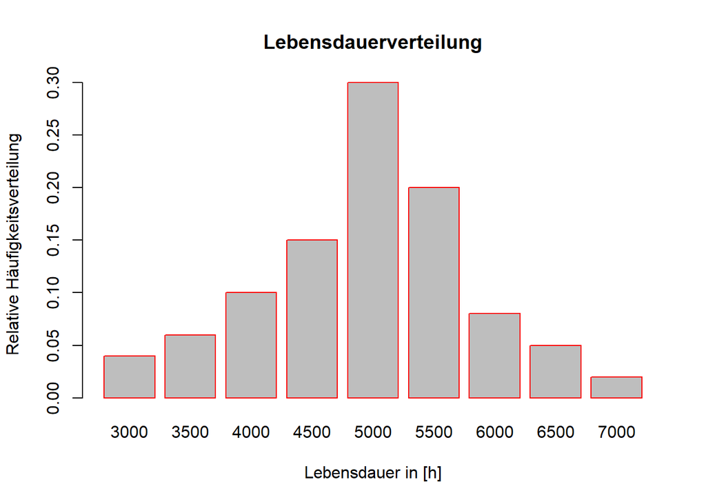

```r
barplot(lt_class_rel_occ.vec,
        names.arg = lt_mids.vec,
        xlab = "Lebensdauer in [h]",
        ylab = "Relative Häufigkeitsverteilung ",
        main = "Lebensdauerverteilung",
        border = "red")
```

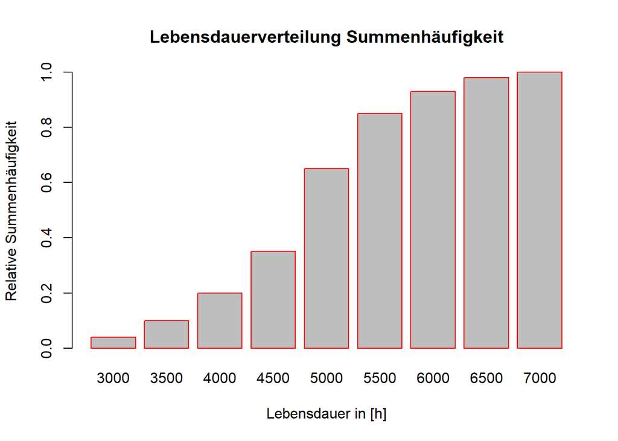

```r
b = barplot(cumsum(lt_class_rel_occ.vec),
        names.arg = lt_mids.vec,
        xlab = "Lebensdauer in [h]",
        ylab = "Relative Summenhäufigkeit",
        main = "Lebensdauerverteilung Summenhäufigkeit",
        border = "red")
```

# B-2)

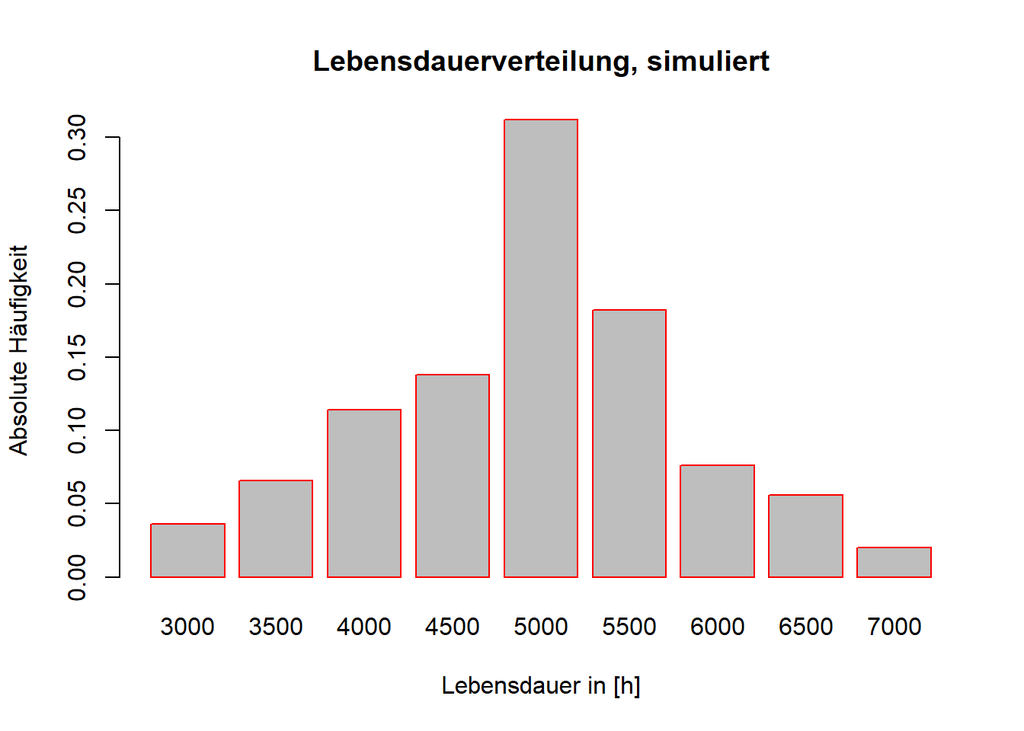

```r
lt_sim_classes.tab = table(cut(runif(500), breaks = c(0, cumsum(lt_class_rel_occ.vec)) , right = TRUE))

barplot(lt_sim_classes.tab / 500,
        xlab = "Lebensdauer in [h]",
        ylab = "Absolute Häufigkeit",
        main = "Lebensdauerverteilung, simuliert",
        names.arg = lt_mids.vec,
        border = "red")
```

```r
# Create a table with uniform distributed numbers with count of lt_simulated per bin in the classes
lt_simulated = c()
for (i in 1:9){
  # Append the uniform distributed values n times to the vector lt_simulated
  lt_simulated = c(lt_simulated,
           runif(
        n = lt_sim_classes.tab[[i]],
        min = (lt_mids.vec[i]) - lt_class_broadness.vec[i] / 2,
        max = (lt_mids.vec[i]) + lt_class_broadness.vec[i] / 2)
        )
}
# Crosscheck for standard deviation and mean
mean(lt_simulated)
```

```
## [1] 4937.623
```

```r
sd(lt_simulated)
```

```
## [1] 878.238
```

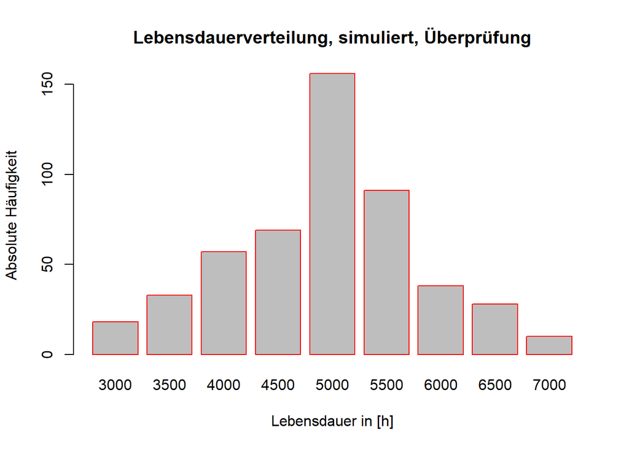

```r
lt_simulated.tab = table(cut(lt_simulated, breaks = lt_class_breaks.vec))
# Crosscheck the new generated data
barplot(lt_simulated.tab,
        xlab = "Lebensdauer in [h]",
        ylab = "Absolute Häufigkeit",
        main = "Lebensdauerverteilung, simuliert, Überprüfung",
        names.arg = lt_mids.vec,
        border = "red")
```

# B-3)

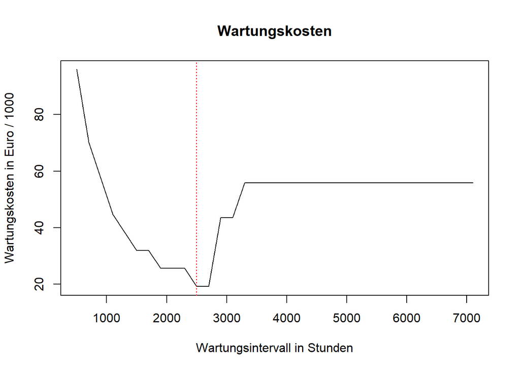

```r
Ka = 18600
Kv = 6400
Tsim = 7250
tau.vec = seq(500, Tsim, 200)
Kges = c()

for (j in 1:length(tau.vec)){
  tau = tau.vec[j]

  i = 1
  ti = 0
  za = 0
  zv = 0

  while(TRUE){
    xi <- lt_simulated[i]
    if (xi > tau){
      ti = ti + tau
      zv = zv + 1
    }else{
      ti = ti + xi
      za = za + 1
    }
    if(ti > Tsim || i >= length(lt_simulated)){
      break
    }
    i = i + 1
  }
  Kges[j] = Ka*za + Kv*zv
}

min = min(Kges)

plot(tau.vec, Kges/1000, type="l",
     main = "Wartungskosten",
     xlab = "Wartungsintervall in Stunden",
     ylab = "Wartungskosten in Euro / 1000"
     )
min_tau = tau.vec[Kges == min][1]
abline(v=min_tau, col="red", lty = 3)
```

```r
cat("Minimale kosten sind: ", min, "Euro")
```

```
## Minimale kosten sind:  19200 Euro
```

```r
cat("Bei ", min_tau, " Stunden")
```

```
## Bei  2500  Stunden
```